# Association Rules Visualization - Exercices

## Instalación y configuración de arulesViz

Instalar el paquete arulesViz

```r
#install.packages("arulesViz")
```

Cargar la librería arulesViz (carga automáticamente arules)

```r
library("arulesViz")
```

## arulesViz con dataset Groceries

El dataset Groceries contiene información de ventas de una tienda de abarrotes con 9835 transaccionesy 169 items (grupos de productos).

```r
data("Groceries")
summary(Groceries)
```

```
transactions as itemMatrix in sparse format with
 9835 rows (elements/itemsets/transactions) and
 169 columns (items) and a density of 0.02609146

most frequent items:
      whole milk other vegetables       rolls/buns             soda           yogurt          (Other)
            2513             1903             1809             1715             1372            34055

element (itemset/transaction) length distribution:
sizes
   1    2    3    4    5    6    7    8    9   10   11   12   13   14   15   16   17   18   19   20   21   22   23   24   26
2159 1643 1299 1005  855  645  545  438  350  246  182  117   78   77   55   46   29   14   14    9   11    4    6    1    1
  27   28   29   32
   1    1    3    1

   Min. 1st Qu.  Median    Mean 3rd Qu.    Max.
  1.000   2.000   3.000   4.409   6.000  32.000

includes extended item information - examples:
```

|  | labels | level2 | level1 |
| --- | --- | --- | --- |
| 1 | frankfurter | sausage | meat and sausage |
| 2 | sausage | sausage | meat and sausage |
| 3 | liver loaf | sausage | meat and sausage |

Responde a las siguientes preguntas de acuerdo a la información del paso anterior: - ¿Cuál es el valor de la métrica density? - Con base density, ¿consideras que la matriz de transacciones de Groceries es densa o dispersa? - ¿Cuántos items hay en la trasacción promedio? - ¿Cuál es el producto más popular?

Efectuaremos minería de reglas de asociación por medio del algoritmo Apriori implementado en arules.

```r
rules <- apriori(Groceries, parameter = list(support = 0.001, confidence = 0.05))
```

```
Apriori

Parameter specification:
```

|  | confidence | minval | smax | arem | aval | originalSupport | maxtime | support | minlen | maxlen | target | ext |
| --- | --- | --- | --- | --- | --- | --- | --- | --- | --- | --- | --- | --- |
|  | 0.05 | 0.1 | 1 | none | FALSE | TRUE | 5 | 0.001 | 1 | 10 | rules | TRUE |

```
Algorithmic control:
```

|  | filter | tree | heap | memopt | load | sort | verbose |
| --- | --- | --- | --- | --- | --- | --- | --- |
|  | 0.1 | TRUE | TRUE | FALSE | TRUE | 2 | TRUE |

```
Absolute minimum support count: 9

set item appearances ...[0 item(s)] done [0.00s].
set transactions ...[169 item(s), 9835 transaction(s)] done [0.01s].
sorting and recoding items ... [157 item(s)] done [0.00s].
creating transaction tree ... done [0.00s].
checking subsets of size 1 2 3 4 5 6 done [0.02s].
writing ... [37965 rule(s)] done [0.04s].
creating S4 object  ... done [0.02s].
```

```r
summary(rules)
```

```
set of 37965 rules

rule length distribution (lhs + rhs):sizes
    1     2     3     4     5     6
   28  3814 19639 12544  1880    60

   Min. 1st Qu.  Median    Mean 3rd Qu.    Max.
  1.000   3.000   3.000   3.332   4.000   6.000

summary of quality measures:
    support           confidence        coverage             lift             count
 Min.   :0.001017   Min.   :0.0500   Min.   :0.001017   Min.   : 0.4193   Min.   :  10.00
 1st Qu.:0.001118   1st Qu.:0.1358   1st Qu.:0.003864   1st Qu.: 1.8718   1st Qu.:  11.00
 Median :0.001423   Median :0.2273   Median :0.006914   Median : 2.4718   Median :  14.00
 Mean   :0.002133   Mean   :0.2796   Mean   :0.012891   Mean   : 2.7424   Mean   :  20.98
 3rd Qu.:0.002034   3rd Qu.:0.3846   3rd Qu.:0.013218   3rd Qu.: 3.2952   3rd Qu.:  20.00
 Max.   :0.255516   Max.   :1.0000   Max.   :1.000000   Max.   :35.7158   Max.   :2513.00

mining info:
```

|  | data | ntransactions | support | confidence |
| --- | --- | --- | --- | --- |
|  | Groceries | 9835 | 0.001 | 0.05 |

Obtenemos las primeras tres reglas respecto a la métrica lift, que es una métrica popular de la fuerza de la regla.

|  | lhs |  | rhs | support | confidence | coverage | lift | count |
| --- | --- | --- | --- | --- | --- | --- | --- | --- |
| [1] | {bottled beer,red/blush wine} | => | {liquor} | 0.001931876 | 0.3958333 | 0.004880529 | 35.71579 | 19 |
| [2] | {hamburger meat,soda} | => | {Instant food products} | 0.001220132 | 0.2105263 | 0.005795628 | 26.20919 | 12 |
| [3] | {ham,white bread} | => | {processed cheese} | 0.001931876 | 0.3800000 | 0.005083884 | 22.92822 | 19 |

```r
args(getS3method("plot", "rules"))
```

```
function (x, method = NULL, measure = "support", shading = "lift",
    interactive = NULL, engine = "default", data = NULL,
    control = NULL, ...)
NULL
```

x representa el conjunto de reglas a ser vizualizadas, method es el método de visualización y meadure y shading contienen las mediciones de interés empleadas por la gráfica. Por medio de engine es posible usasr diversos motores de graficación para visualizar la gráfica. El motor predeterminado típicamente usa grid, muchas gráficas pueden ser visualizadas con el motor "htmlwidget" en cual resulta en un widget HTML.

## Preparación de datos para arules

## Técnicas y ejemplos de visualización con arulesViz

### Scatter plot

Es posible lograr una visualización simple de reglas de asociación por medio de la gráfica scatter plot con dos medidas de interés en los ejes. El método por omisión de reglas de asociación en arulesViz es el scatter plot empleando support y confidence en los ejes.. También se usa una tercera medición (lift, por omisión) como el color (o escala de grises de los puntos). Se incluye una escala del rango de valores que corresponde a los colores.

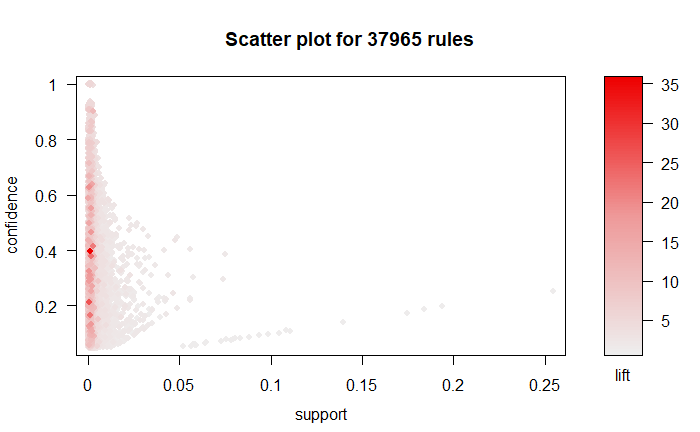

Analiza la gráfica, identifica las reglas que tengan un valores altos en la medición lift e indica para ellas si el valor de support es alto o bajo.

Crea una gráfica scatter plot con support y confidence en los ejes, empleando coverage como medición asociada a la escala de colores.

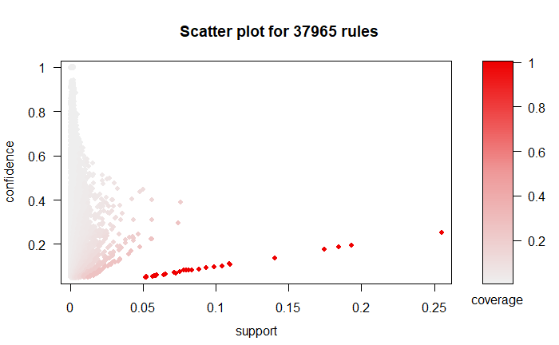

```r
plot(rules, shading = "coverage")
```